# Analysis and Predictor of Senate Elections 2017

```python
import numpy as np
import pandas as pd
import matplotlib.pyplot as plt
import seaborn as sns
%matplotlib inline
```

## load data

```python
df_2013 = pd.read_csv('2013_final/senate_2013.csv') #2013 winners
```

```python
df_nom = pd.read_csv('nominations_data/senate_nom.csv') # Primary candidates vying for nominations
```

```python
df_cand = pd.read_csv('candidates_data/senate_2017.csv') #Party candidate / Independent
```

```python
df_2017 = pd.read_csv('2017_final/senate_2017.csv') # 2017 winners
```

## Clean 2013 Data

```python
df_2013.head(2)
```

|  | County Code | Unnamed: 1 | Unnamed: 2 | Unnamed: 3 | County Name | Unnamed: 5 | Unnamed: 6 | Unnamed: 7 | Unnamed: 8 | Unnamed: 9 | ... | Unnamed: 11 | Unnamed: 12 | Unnamed: 13 | Unnamed: 14 | Unnamed: 15 | Unnamed: 16 | Full Names B | Unnamed: 18 | Unnamed: 19 | Party/Independent Candidate |
| --- | --- | --- | --- | --- | --- | --- | --- | --- | --- | --- | --- | --- | --- | --- | --- | --- | --- | --- | --- | --- | --- |
| 0 | 1 | NaN | NaN | NaN | Mombasa | NaN | NaN | NaN | NaN | NaN | ... | NaN | NaN | NaN | NaN | NaN | NaN | Hassan | NaN | NaN | Wiper Democratic Movement- Kenya |
| 1 | 2 | NaN | NaN | NaN | Kwale | NaN | NaN | NaN | NaN | NaN | ... | NaN | NaN | NaN | NaN | NaN | NaN | Boy | NaN | NaN | Orange Democratic Movement |

2 rows × 21 columns

```python
df_2013.dropna(axis=1,inplace=True)
```

### join first and last names

```python
df_2013['name'] = df_2013[['Full Names A','Full Names B']].apply(lambda x: ' '.join(x), axis=1).str.lower()
```

```python
df_2013 = df_2013[['County Code','County Name','name', 'Party/Independent Candidate']]
```

```python
df_2013.columns = ['c_code','county','name','party']
```

```python
df_2013.head(3)
```

|  | c_code | county | name | party |
| --- | --- | --- | --- | --- |
| 0 | 1 | Mombasa | hassan omar hassan | Wiper Democratic Movement- Kenya |
| 1 | 2 | Kwale | boy juma boy | Orange Democratic Movement |
| 2 | 3 | Kilifi | stewart mwachiru shadrack madzayo | Orange Democratic Movement |

```python
df_2013.info()
```

```
<class 'pandas.core.frame.DataFrame'>
RangeIndex: 47 entries, 0 to 46
Data columns (total 4 columns):
c_code    47 non-null int64
county    47 non-null object
name      47 non-null object
party     47 non-null object
dtypes: int64(1), object(3)
memory usage: 1.5+ KB
```

## Clean 2017 Data

```python
df_2017.head(2)
```

|  | c_code | county | name | gender | birth_date | party_name | elected |
| --- | --- | --- | --- | --- | --- | --- | --- |
| 0 | 30 | Baringo | Gideon Kipsielei Towett Moi | Male | NaN | Kenya African National Union | True |
| 1 | 36 | Bomet | Christopher Andrew Langat | Male | NaN | Jubilee Party | True |

```python
df_2017.columns = ['c_code','county','name','gender', 'dob', 'party','elected']
```

```python
df_2017['name'] = df_2017['name'].str.lower()
```

```python
df_2017.head(2)
```

|  | c_code | county | name | gender | dob | party | elected |
| --- | --- | --- | --- | --- | --- | --- | --- |
| 0 | 30 | Baringo | gideon kipsielei towett moi | Male | NaN | Kenya African National Union | True |
| 1 | 36 | Bomet | christopher andrew langat | Male | NaN | Jubilee Party | True |

```python
df_2017.info()
```

```
<class 'pandas.core.frame.DataFrame'>
RangeIndex: 47 entries, 0 to 46
Data columns (total 7 columns):
c_code     47 non-null int64
county     47 non-null object
name       47 non-null object
gender     47 non-null object
dob        8 non-null object
party      47 non-null object
elected    47 non-null bool
dtypes: bool(1), int64(1), object(5)
memory usage: 2.3+ KB
```

## Clean Nomination 2017 Data

```python
df_nom.head(3)
```

|  | County Code | County Name | Surname | Other Name | ID. No. | YOB | PWD | Gender | Party | Party_abv |
| --- | --- | --- | --- | --- | --- | --- | --- | --- | --- | --- |
| 0 | 1 | Mombasa | Kassim | Abdusalaam Ali | 10093749 | 1/1/1970 | No | Male | JUBILEE PARTY | JP |
| 1 | 1 | Mombasa | Swabir | Abuubakar Mahadhi | 30474451 | 8/13/1992 | No | Male | JUBILEE PARTY | JP |
| 2 | 1 | Mombasa | Katana | Hazel Nyamoki | 6729577 | 4/1/1959 | No | Female | JUBILEE PARTY | JP |

```python
df_nom['name'] = df_nom[['Other Name','Surname']].apply(lambda x: ' '.join(x), axis=1).str.lower()
df_nom['County Name'] = df_nom['County Name'].str.lower()
df_nom['Gender'] = df_nom['Gender'].str.lower()
```

```python
df_nom = df_nom.drop(['Surname','Other Name'],axis=1)
```

```python
df_nom.head(2)
```

|  | County Code | County Name | ID. No. | YOB | PWD | Gender | Party | Party_abv | name |
| --- | --- | --- | --- | --- | --- | --- | --- | --- | --- |
| 0 | 1 | mombasa | 10093749 | 1/1/1970 | No | male | JUBILEE PARTY | JP | abdusalaam ali kassim |
| 1 | 1 | mombasa | 30474451 | 8/13/1992 | No | male | JUBILEE PARTY | JP | abuubakar mahadhi swabir |

```python
df_nom.columns = ['c_code','county','id_no','yob','pwd','gender','party','party_abv','name']
```

```python
df_nom = df_nom[['c_code','county','name','id_no','yob','pwd','gender','party_abv']]
```

```python
df_nom.head(3)
```

|  | c_code | county | name | id_no | yob | pwd | gender | party_abv |
| --- | --- | --- | --- | --- | --- | --- | --- | --- |
| 0 | 1 | mombasa | abdusalaam ali kassim | 10093749 | 1/1/1970 | No | male | JP |
| 1 | 1 | mombasa | abuubakar mahadhi swabir | 30474451 | 8/13/1992 | No | male | JP |
| 2 | 1 | mombasa | hazel nyamoki katana | 6729577 | 4/1/1959 | No | female | JP |

```python
df_nom.info()
```

```
<class 'pandas.core.frame.DataFrame'>
RangeIndex: 236 entries, 0 to 235
Data columns (total 8 columns):
c_code       236 non-null int64
county       236 non-null object
name         236 non-null object
id_no        233 non-null object
yob          172 non-null object
pwd          169 non-null object
gender       235 non-null object
party_abv    236 non-null object
dtypes: int64(1), object(7)
memory usage: 14.8+ KB
```

## Clean Candidates 2017 Data

```python
df_cand.head(3)
```

|  | No | Surname | Other Names | County Code | County Name | Party Code | Political Party Name | Abbrv | Gender |
| --- | --- | --- | --- | --- | --- | --- | --- | --- | --- |
| 0 | 1 | BAJABER | YASSER ALI SHEIKH | 1 | MOMBASA | 23 | FORUM FOR RESTORATION OF DEMOCRACY-KENYA | FORD-KENYA | Male |
| 1 | 2 | CHOME | ONESMAS HABEL | 1 | MOMBASA | 42 | SHIRIKISHO PARTY OF KENYA | SPK | Male |
| 2 | 3 | FONDO | FLORENCE WAWUDA | 1 | MOMBASA | 60 | VIBRANT DEMOCRATIC PARTY | VDP | Female |

```python
df_cand['name'] = df_cand[['Other Names','Surname']].apply(lambda x: ' '.join(x), axis=1).str.lower()
df_cand['County Name'] = df_cand['County Name'].str.lower()
df_cand['Gender'] = df_cand['Gender'].str.lower()
```

```python
df_cand = df_cand.drop(['Surname','Other Names'],axis=1)
```

```python
df_cand = df_cand[['County Code', 'County Name', 'name','Gender','Abbrv']]
```

```python
df_cand.columns = ['c_code','county','name','gender','party_abv']
```

```python
df_cand.head(3)
```

|  | c_code | county | name | gender | party_abv |
| --- | --- | --- | --- | --- | --- |
| 0 | 1 | mombasa | yasser ali sheikh bajaber | male | FORD-KENYA |
| 1 | 1 | mombasa | onesmas habel chome | male | SPK |
| 2 | 1 | mombasa | florence wawuda fondo | female | VDP |

```python
df_cand.info()
```

```
<class 'pandas.core.frame.DataFrame'>
RangeIndex: 257 entries, 0 to 256
Data columns (total 5 columns):
c_code       257 non-null int64
county       257 non-null object
name         257 non-null object
gender       257 non-null object
party_abv    257 non-null object
dtypes: int64(1), object(4)
memory usage: 10.1+ KB
```

### Merge the details from all the dataset

```python
df_2013.columns
```

```
Index(['c_code', 'county', 'name', 'party'], dtype='object')
```

```python
df_2017.columns
```

```
Index(['c_code', 'county', 'name', 'gender', 'dob', 'party', 'elected'], dtype='object')
```

```python
df_nom.columns
```

```
Index(['c_code', 'county', 'name', 'id_no', 'yob', 'pwd', 'gender',
       'party_abv'],
      dtype='object')
```

```python
df_cand.columns
```

```
Index(['c_code', 'county', 'name', 'gender', 'party_abv'], dtype='object')
```

**Projected steps**

- concat nominations and final candidates datasets
- add column `2013` with a yes(1) or No(0) to this dataset
- add `won` column with yes(1) or No(0)

### i. concat nominations and final candidates datasets

```python
candidates = pd.merge(df_nom,df_cand,how='outer')
```

```python
candidates.info()
```

```
<class 'pandas.core.frame.DataFrame'>
Int64Index: 444 entries, 0 to 443
Data columns (total 8 columns):
c_code       444 non-null int64
county       444 non-null object
name         444 non-null object
id_no        233 non-null object
yob          172 non-null object
pwd          169 non-null object
gender       443 non-null object
party_abv    444 non-null object
dtypes: int64(1), object(7)
memory usage: 31.2+ KB
```

**fill `age` with mean `yob`**

```python
candidates['age'] = 2017 - (candidates['yob'].str.split('/').str.get(2).apply(pd.to_numeric))
```

```python
candidates['age'] = candidates['age'].fillna(candidates['age'].mean()).round(0).astype(int)
```

```python
candidates.info()
```

```
<class 'pandas.core.frame.DataFrame'>
Int64Index: 444 entries, 0 to 443
Data columns (total 9 columns):
c_code       444 non-null int64
county       444 non-null object
name         444 non-null object
id_no        233 non-null object
yob          172 non-null object
pwd          169 non-null object
gender       443 non-null object
party_abv    444 non-null object
age          444 non-null int64
dtypes: int64(2), object(7)
memory usage: 34.7+ KB
```

#### a simple heatmap to see where we are missing data!

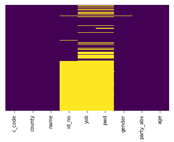

```python
sns.heatmap(candidates.isnull(),yticklabels=False,cbar=False,cmap='viridis')
```

### Indicate those who won in_2013 with a `True-(1)` or `False-(0)` to this dataset

```python
sen_2013 = list(df_2013['name'])
```

```python
def check_2013(name):
    if name in sen_2013:
        return 1
    else:
        return 0
```

```python
candidates['won_2013'] = candidates['name'].apply(check_2013)
```

### Indicate 2017 winners with a yes-(1) or no-(0) in `elected` column

```python
sen_2017 = list(df_2017['name'])
```

```python
def won2017(name):
    if name in sen_2017:
        return 1
    else:
        return 0
```

```python
candidates['elected'] = candidates['name'].apply(won2017)
```

#### Map party_Abv to respective code

```python
p_code = {'NARC-KENYA':1, 'NVP':2, 'LPK':3, 'CMD':5, 'PICK':7, 'RBK':8, 'KNC':9, 'MGPK':10, 'WDM-K':12, 'DP':13, 'PNU':14, 'PDR':15, 'AGANO':17, 'KSC':19, 'ODM':21, 'PPK':22, 'FORD-KENYA':23, 'PPOK':25, 'JP':27, 'MDP':28, 'NARC':29, 'KADU-ASILI':30, 'KPP':31, 'SDP':32, 'KANU':33, 'SAFINA':34, 'CCU':36, 'NAPK':37, 'PEP':38, 'PDP':39, 'ND':40, 'UDM':41, 'SPK':42, 'PDU':44, 'FAP':46, 'FP':47, 'EFP':48, 'FPK':49, 'MUUNGANO':50, 'NPK':51, 'MSS':52, 'KENDA':53, 'CCM':54, 'ARK':55, 'FORD':56, 'RLP':58, 'RPK':59, 'VDP':60, 'CCP':61, 'ANC':62, 'DPK':63, 'UDP':64, 'DDA':65, 'PTP':66, 'MCCP':67, 'DC':68, 'LDP':69, 'GCK':70, 'NLP':71, 'MDG':72, 'ALPK':73, 'UP':74, 'ELP':75, 'TAK':76, 'JFP':77, 'IND':100}
```

```python
candidates['p_code'] = candidates['party_abv'].map(p_code)
```

```python
candidates['party_abv'].unique()
```

```
array(['JP', 'ODM', 'WDM-K', 'ANC', 'NARC-KENYA', 'CCM', 'FORD-KENYA',
       'SPK', 'VDP', 'IND', 'MCCP', 'ALPK', 'ELP', 'KADU-ASILI', 'KANU',
       'DP', 'CMD', 'UDP', 'NVP', 'PDR', 'KPP', 'SAFINA', 'AGANO', 'SDP',
       'TAK', 'JFP', 'EFP', 'LPK', 'FAP', 'PNU', 'MGPK', 'FORD', 'CCU',
       'PTP', 'ND', 'MDP', 'NLP', 'FPK', 'PPOK', 'MDG', 'RBK', 'UDM',
       'KNC', 'PEP', 'PDP', 'KSC', 'RLP'], dtype=object)
```

```python
candidates['pwd'].value_counts()
```

```
No      156
None      6
ND        6
Yes       1
Name: pwd, dtype: int64
```

```python
# from fuzzywuzzy import fuzz, process
# fuzz.ratio(df_2013['name'][0],candidates['name'][2])
```

```python
# candidates.to_csv('senate_candidates.csv')
```

# EDA

load candidates data

```python
df = pd.read_csv('senate_candidates.csv')
```

```python
df.head(2)
```

|  | Unnamed: 0 | c_code | county | name | id_no | yob | pwd | gender | party_abv | age | won_2013 | elected | p_code |
| --- | --- | --- | --- | --- | --- | --- | --- | --- | --- | --- | --- | --- | --- |
| 0 | 0 | 1 | mombasa | abdusalaam ali kassim | 10093749 | 1/1/1970 | No | male | JP | 47 | 0 | 0 | 27 |
| 1 | 1 | 1 | mombasa | abuubakar mahadhi swabir | 30474451 | 8/13/1992 | No | male | JP | 25 | 0 | 0 | 27 |

### Missing Data

Use a heatmap to see where we are missing data!

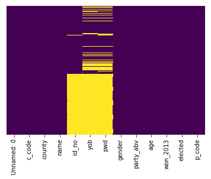

```python
sns.heatmap(df.isnull(),yticklabels=False,cbar=False,cmap='viridis')

# An assessment of data available, id_no, yob and pwd have missing values while the rest
# are relatively OK.
#
```

```python
# drop column I wont use
df.drop(['Unnamed: 0','id_no', 'yob','pwd'], axis=1, inplace=True)
```

# Visualizing some more of the data

#### Analysis by column.

**By Elected**

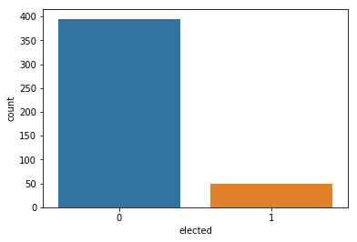

```python
sns.countplot(x='elected',data=df)
```

**Elected by Gender**

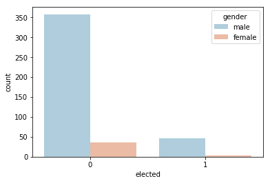

```python
sns.countplot(x='elected',hue='gender',data=df,palette='RdBu_r')
```

#### Election by Party

Top 10 parties by count

```python
df['party_abv'].value_counts()[:10]
```

```
JP            173
ODM            75
IND            44
WDM-K          20
KANU           17
ANC            14
MCCP           12
FORD-KENYA     12
NARC-KENYA      8
CCM             5
Name: party_abv, dtype: int64
```

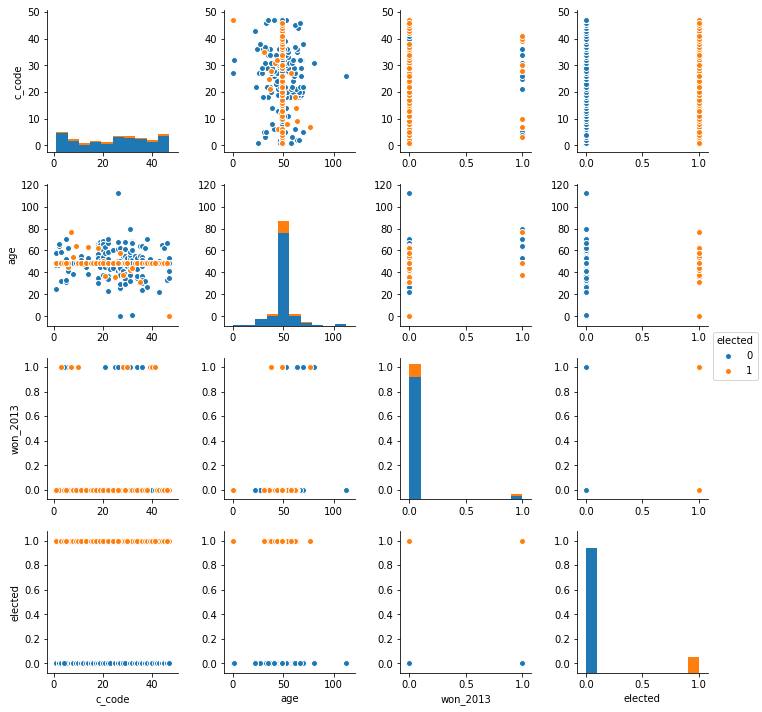

```python
sns.pairplot(data=df,hue='elected')
```

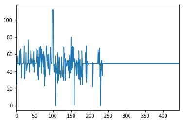

```python
df['age'].plot()
```

```python
df.head(3)
```

|  | c_code | county | name | gender | party_abv | age | won_2013 | elected | p_code |
| --- | --- | --- | --- | --- | --- | --- | --- | --- | --- |
| 0 | 1 | mombasa | abdusalaam ali kassim | male | JP | 47 | 0 | 0 | 27 |
| 1 | 1 | mombasa | abuubakar mahadhi swabir | male | JP | 25 | 0 | 0 | 27 |
| 2 | 1 | mombasa | hazel nyamoki katana | female | JP | 58 | 0 | 0 | 27 |

## Convert Categorical Features

We need to convert categorical features to dummy variables using pandas,

Otherwise the learning algorithm won't be able to directly take in those features as inputs.

```
- gender column, caterorize if candidate is male or not(1 | 0 )
- party_abv, categorize for the 47 parties
```

```python
gender = pd.get_dummies(df['gender'],drop_first=True)

# party = pd.get_dummies(df['party_abv'],drop_first=True)
```

```python
df_train = pd.concat([df,gender],axis=1)
```

```python
df_train.head(2)
```

|  | c_code | county | name | gender | party_abv | age | won_2013 | elected | p_code | male |
| --- | --- | --- | --- | --- | --- | --- | --- | --- | --- | --- |
| 0 | 1 | mombasa | abdusalaam ali kassim | male | JP | 47 | 0 | 0 | 27 | 1 |
| 1 | 1 | mombasa | abuubakar mahadhi swabir | male | JP | 25 | 0 | 0 | 27 | 1 |

```python
df_train.drop(['county','name','gender','party_abv'],axis=1,inplace=True)
```

```python
df_train.head(2)
```

|  | c_code | age | won_2013 | elected | p_code | male |
| --- | --- | --- | --- | --- | --- | --- |
| 0 | 1 | 47 | 0 | 0 | 27 | 1 |
| 1 | 1 | 25 | 0 | 0 | 27 | 1 |

## Building a Logistic Regression model

Start by splitting data into a training set and test set

## Train Test Split

```
X = These are the features we will use to predict

y = Value we are predicting ie Did the candidate win
```

```python
from sklearn.model_selection import train_test_split
```

```python
X = df_train.drop('elected',axis=1)
y = df_train['elected']

X_train, X_test, y_train, y_test = train_test_split(X, y, test_size=0.2, random_state=41)
```

**Training and fitting**

```python
from sklearn.linear_model import LogisticRegression
```

```python
lr = LogisticRegression()
```

```python
lr.fit(X_train,y_train)
```

```
LogisticRegression(C=1.0, class_weight=None, dual=False, fit_intercept=True,
          intercept_scaling=1, max_iter=100, multi_class='ovr', n_jobs=1,
          penalty='l2', random_state=None, solver='liblinear', tol=0.0001,
          verbose=0, warm_start=False)
```

**Predict using the model**

```python
pred = lr.predict(X_test)
```

## Evaluate the Model

Using classification report, We can check :

```
- precision (ratio of correctly predicted positive observations to the total predicted positive observations)
- recall (ratio of correctly predicted positive observations to the all observations in actual class)
- f1-score (measure of a test's accuracy)
```

```python
from sklearn.metrics import classification_report, confusion_matrix
```

```python
print(confusion_matrix(pred,y_test))
print('-- -- -- --')
print (classification_report(pred,y_test))
```

```
[[80  9]
 [ 0  0]]
-- -- -- --
             precision    recall  f1-score   support

          0       1.00      0.90      0.95        89
          1       0.00      0.00      0.00         0

avg / total       1.00      0.90      0.95        89
```

# PCA

scale the data so that each feature has a single unit variance.

```python
from sklearn.preprocessing import StandardScaler
```

```python
# Instatiate the scaler
scaler = StandardScaler()
```

```python
scaler.fit(df_train)
```

```
StandardScaler(copy=True, with_mean=True, with_std=True)
```

```python
scaled_data = scaler.transform(df_train)
```

#### PCA with Scikit Learn

uses a very similar process to other preprocessing functions that come with SciKit Learn.

```
- Instantiate a PCA object,
- find the principal components using the fit method,
- Apply the rotation and dimensionality reduction by calling transform().
```

We can also specify how many components we want to keep when creating the PCA object.

```python
from sklearn.decomposition import PCA
```

```python
pca = PCA(n_components=2)
```

```python
pca.fit(scaled_data)
```

```
PCA(copy=True, iterated_power='auto', n_components=2, random_state=None,
  svd_solver='auto', tol=0.0, whiten=False)
```

**Transform this data to its first 2 principal components.**

```python
x_pca = pca.transform(scaled_data)
```

```python
scaled_data.shape
```

```
(444, 6)
```

```python
x_pca.shape
```

```
(444, 2)
```

With a reduction from 6 to 2! plot these two dimensions out!

- Blue -> `lost` | Red -> `won`

```
Text(0,0.5,'Second Principal Component')
```

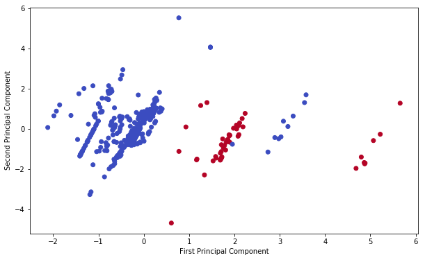

```python
plt.figure(figsize=(10,6))
plt.scatter(x_pca[:,0],x_pca[:,1],c=df_train['elected'],cmap='coolwarm' )
plt.xlabel('First Principal Component')
plt.ylabel('Second Principal Component')
```

## Random Forests

```python
from sklearn.ensemble import RandomForestClassifier
```

```python
rfc = RandomForestClassifier(n_estimators=200)
```

```python
rfc.fit(X_train, y_train)
```

```
RandomForestClassifier(bootstrap=True, class_weight=None, criterion='gini',
            max_depth=None, max_features='auto', max_leaf_nodes=None,
            min_impurity_decrease=0.0, min_impurity_split=None,
            min_samples_leaf=1, min_samples_split=2,
            min_weight_fraction_leaf=0.0, n_estimators=200, n_jobs=1,
            oob_score=False, random_state=None, verbose=0,
            warm_start=False)
```

```python
rfc_pred = rfc.predict(X_test)
```

```python
#Evaluate
```

```python
print(confusion_matrix(rfc_pred,y_test))
print('-- -- -- --')
print(classification_report(rfc_pred,y_test))
```

```
[[76  9]
 [ 4  0]]
-- -- -- --
             precision    recall  f1-score   support

          0       0.95      0.89      0.92        85
          1       0.00      0.00      0.00         4

avg / total       0.91      0.85      0.88        89
```

## Decision Tree

```python
from sklearn.tree import DecisionTreeClassifier
```

```python
dtree = DecisionTreeClassifier()
```

```python
dtree.fit(X_train,y_train)
```

```
DecisionTreeClassifier(class_weight=None, criterion='gini', max_depth=None,
            max_features=None, max_leaf_nodes=None,
            min_impurity_decrease=0.0, min_impurity_split=None,
            min_samples_leaf=1, min_samples_split=2,
            min_weight_fraction_leaf=0.0, presort=False, random_state=None,
            splitter='best')
```

```python
dtree_pred = dtree.predict(X_test)
```

```python
print(confusion_matrix(rfc_pred,y_test))
print('-- -- -- --')
print(classification_report(rfc_pred,y_test))
```

```
[[76  9]
 [ 4  0]]
-- -- -- --
             precision    recall  f1-score   support

          0       0.95      0.89      0.92        85
          1       0.00      0.00      0.00         4

avg / total       0.91      0.85      0.88        89
```

# Tree Visualization

Display using sklearn built-in visualization capabilities for decision trees

```python
from IPython.display import Image
from sklearn.externals.six import StringIO
from sklearn.tree import export_graphviz
import pydot

features = list(df_train.drop('elected',axis=1))
features
```

```
['c_code', 'age', 'won_2013', 'p_code', 'male']
```

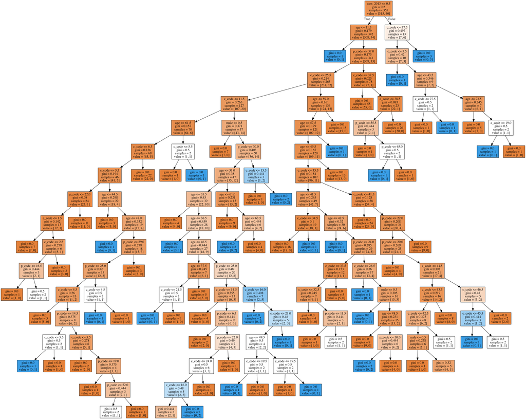

```python
dot_data = StringIO()
export_graphviz(dtree, out_file=dot_data,feature_names=features,
               filled=True, )

graph = pydot.graph_from_dot_data(dot_data.getvalue())
Image(graph[0].create_png())
```